# Karen’s Basket — Perturbation Analysis

# 4 Three perturbed baskets

Item count per perturbed basket

| Basket | Items |
| --- | --- |
| Karen-Lean | 23 |
| Karen-Robust | 28 |
| Karen-Broad | 106 |

## 4.1 Karen-Lean — the strict floor

`Karen-Lean` keeps only the Karen items that earned `verdict == 'keep'` **and** had `n_years >= 5` **and** `n_chains >= 3`. It is the most conservative basket: every item is well-supported by the parquet, but the basket is small, so the resulting index is more vulnerable to single-item volatility (note the 2021 dip in section 5).

Karen-Lean: items that survive strict QC.

| Label | Years | Chains | Rows | Source |
| --- | --- | --- | --- | --- |
| Milk (gallon) | 6 | 108 | 12,651 | karen-original |
| Eggs (dozen) | 6 | 109 | 10,482 | karen-original |
| Ice Cream | 6 | 46 | 4,985 | karen-original |
| Skippy Peanut Butter | 6 | 52 | 4,668 | karen-original |
| Lay’s Potato Chips | 6 | 48 | 4,660 | karen-original |
| Philadelphia Cream Cheese | 6 | 49 | 2,540 | karen-original |
| StarKist Tuna | 6 | 15 | 1,545 | karen-original |
| Bertoli Marinara Sauce | 6 | 20 | 1,012 | karen-original |
| Green Giant Corn | 6 | 15 | 878 | karen-original |
| Romaine Lettuce | 6 | 32 | 817 | karen-original |
| Ocean Spray Cranberry Sauce | 6 | 20 | 725 | karen-original |
| Heinz Ketchup | 6 | 22 | 646 | karen-original |
| Kraft Salad Dressing | 6 | 25 | 606 | karen-original |
| Palmolive Dish Soap | 6 | 15 | 569 | karen-original |
| Dial Bar Soap | 6 | 15 | 418 | karen-original |
| Boar’s Head Turkey | 6 | 7 | 392 | karen-original |
| Sara Lee Bread | 5 | 9 | 201 | karen-original |
| Folgers Coffee | 6 | 14 | 189 | karen-original |
| Welch’s Grape Jelly | 6 | 9 | 180 | karen-original |
| Charmin Toilet Paper | 6 | 18 | 175 | karen-original |
| Birds Eye Frozen Peas | 5 | 6 | 166 | karen-original |
| Kellogg’s Corn Flakes | 6 | 7 | 135 | karen-original |
| Wonder Bread | 5 | 8 | 57 | karen-original |

## 4.2 Karen-Robust — Karen with role-matched substitutes

`Karen-Robust` starts from `Karen-Lean` and refills each missing **conceptual role** (e.g., deli turkey, sandwich bread, bacon, sliced cheese) with the strongest parquet-verified candidate that fits that role. This is the primary recommendation for sensitivity analysis: it preserves Karen’s structure while patching the items where Karen’s narrow brand-anchored regex made the panel brittle.

Karen-Robust: lean items + parquet-verified substitutes for the dropped Karen roles.

| Label | Years | Chains | Rows | Source |
| --- | --- | --- | --- | --- |
| Milk (gallon) | 6 | 108 | 12,651 | karen-original |
| Eggs (dozen) | 6 | 109 | 10,482 | karen-original |
| Ice Cream | 6 | 46 | 4,985 | karen-original |
| Skippy Peanut Butter | 6 | 52 | 4,668 | karen-original |
| Lay’s Potato Chips | 6 | 48 | 4,660 | karen-original |
| Philadelphia Cream Cheese | 6 | 49 | 2,540 | karen-original |
| StarKist Tuna | 6 | 15 | 1,545 | karen-original |
| Bertoli Marinara Sauce | 6 | 20 | 1,012 | karen-original |
| Green Giant Corn | 6 | 15 | 878 | karen-original |
| Romaine Lettuce | 6 | 32 | 817 | karen-original |
| Ocean Spray Cranberry Sauce | 6 | 20 | 725 | karen-original |
| Heinz Ketchup | 6 | 22 | 646 | karen-original |
| Kraft Salad Dressing | 6 | 25 | 606 | karen-original |
| Palmolive Dish Soap | 6 | 15 | 569 | karen-original |
| Dial Bar Soap | 6 | 15 | 418 | karen-original |
| Boar’s Head Turkey | 6 | 7 | 392 | karen-original |
| Sara Lee Bread | 5 | 9 | 201 | karen-original |
| Folgers Coffee | 6 | 14 | 189 | karen-original |
| Welch’s Grape Jelly | 6 | 9 | 180 | karen-original |
| Charmin Toilet Paper | 6 | 18 | 175 | karen-original |
| Birds Eye Frozen Peas | 5 | 6 | 166 | karen-original |
| Kellogg’s Corn Flakes | 6 | 7 | 135 | karen-original |
| Wonder Bread | 5 | 8 | 57 | karen-original |
| Sliced cheese (any) (replaces American Cheese) | 6 | 45 | 2,491 | substitute-for:American Cheese |
| Hot dog / hamburger buns (replaces Ball Park Buns) | 6 | 35 | 781 | substitute-for:Ball Park Buns |
| Deli ham (any brand) (replaces Boar’s Head Ham) | 6 | 37 | 868 | substitute-for:Boar’s Head Ham |
| Chicken drumsticks (replaces Chicken Legs) | 6 | 50 | 1,168 | substitute-for:Chicken Legs |
| Bacon (any brand) (replaces Oscar Mayer Bacon) | 6 | 126 | 9,980 | substitute-for:Oscar Mayer Bacon |

## 4.3 Karen-Broad — Karen plus adjacent items

`Karen-Broad` keeps **all** 60 original Karen items and adds every non-redundant adjacent candidate with `n_years == 6` and `n_rows >= 100`. This basket is the broadest sensitivity test: if our inflation conclusions hold under Karen-Broad, they’re not artefacts of the original 60-item selection.

Karen-Broad ADDITIONS only (the 60 Karen items are also included in this basket). 46 items added, drawn entirely from parquet matches.

| Label | Years | Chains | Rows | Source |
| --- | --- | --- | --- | --- |
| Strawberries | 6 | 105 | 16,690 | adjacent:side.strawberries |
| Bacon (any brand) | 6 | 126 | 9,980 | adjacent:breakfast.bacon |
| Shrimp | 6 | 90 | 9,232 | adjacent:dinner.shrimp |
| Onions | 6 | 118 | 8,526 | adjacent:side.onion |
| Frozen pizza | 6 | 81 | 7,012 | adjacent:frozen.frozen_pizza |
| Greek yogurt | 6 | 68 | 6,963 | adjacent:breakfast.greek_yogurt |
| Broccoli | 6 | 63 | 6,327 | adjacent:side.broccoli |
| Blueberries | 6 | 88 | 5,891 | adjacent:side.blueberries |
| Tortillas | 6 | 73 | 5,507 | adjacent:bread.tortilla |
| Carrots | 6 | 71 | 4,956 | adjacent:side.carrots |
| Block cheddar | 6 | 52 | 4,722 | adjacent:dairy.block_cheddar |
| Bananas | 6 | 83 | 4,685 | adjacent:breakfast.banana |
| Spinach | 6 | 64 | 4,376 | adjacent:side.spinach |
| Breakfast sausage | 6 | 48 | 4,200 | adjacent:breakfast.breakfast_sausage |
| Salmon fillet | 6 | 61 | 4,149 | adjacent:dinner.salmon |
| Salsa | 6 | 55 | 3,906 | adjacent:pantry.salsa |
| Cold cereal (generic) | 6 | 47 | 3,495 | adjacent:breakfast.cold_cereal_generic |
| Sour cream | 6 | 47 | 3,370 | adjacent:dairy.sour_cream |
| Bell peppers | 6 | 86 | 3,124 | adjacent:side.bell_pepper |
| Olive oil | 6 | 49 | 2,864 | adjacent:pantry.olive_oil |
| Tortilla chips | 6 | 51 | 2,656 | adjacent:snack.tortilla_chips |
| Bagels | 6 | 49 | 2,547 | adjacent:breakfast.bagel |
| Sliced cheese (any) | 6 | 45 | 2,491 | adjacent:lunch.sliced_cheese |
| Ribeye steak | 6 | 62 | 2,289 | adjacent:dinner.ribeye |
| Green beans | 6 | 54 | 2,284 | adjacent:side.green_beans |
| Avocados | 6 | 79 | 2,274 | adjacent:side.avocado |
| Black beans (canned) | 6 | 45 | 2,071 | adjacent:pantry.black_beans |
| Frozen french fries | 6 | 31 | 2,047 | adjacent:frozen.frozen_french_fries |
| Shredded cheese | 6 | 36 | 1,674 | adjacent:dairy.shredded_cheese |
| Pork loin / tenderloin | 6 | 51 | 1,634 | adjacent:dinner.pork_loin |
| Chicken thighs | 6 | 47 | 1,504 | adjacent:dinner.bone_in_chicken_thigh |
| Pork chops | 6 | 58 | 1,429 | adjacent:dinner.pork_chop |
| Bottled water (case) | 6 | 50 | 1,415 | adjacent:bev.bottled_water |
| Strip steak | 6 | 45 | 1,328 | adjacent:dinner.strip_steak |
| Canola / vegetable oil | 6 | 26 | 1,301 | adjacent:pantry.canola_oil |
| Chicken drumsticks | 6 | 50 | 1,168 | adjacent:dinner.chicken_drumstick |
| Sports drink | 6 | 23 | 1,035 | adjacent:bev.gatorade |
| Tomato sauce / paste | 6 | 29 | 1,016 | adjacent:pantry.tomato_sauce |
| Granola bars | 6 | 24 | 977 | adjacent:snack.granola_bars |
| Deli ham (any brand) | 6 | 37 | 868 | adjacent:lunch.deli_ham_generic |
| Canned diced tomatoes | 6 | 17 | 852 | adjacent:pantry.diced_tomato |
| Hot dog / hamburger buns | 6 | 35 | 781 | adjacent:bread.hot_dog_bun |
| Chickpeas / garbanzo | 6 | 23 | 631 | adjacent:pantry.chickpeas |
| Domestic beer (12-pack) | 6 | 23 | 481 | adjacent:bev.beer_domestic |
| Whole chicken | 6 | 34 | 434 | adjacent:dinner.whole_chicken |
| Frozen vegetables (mixed) | 6 | 17 | 157 | adjacent:frozen.frozen_vegetables |

# 5 Comparison: how does basket choice move the inflation curve?

For each of the four baskets we compute a simple geometric-mean Laspeyres index, base 2020 = 1.0, using median price by year per label. The basket index for a given year is the unweighted geomean of its per-label indices that have a 2020 baseline.

This is intentionally a quick sensitivity tool, not a publication-grade index — see *Caveats* below.

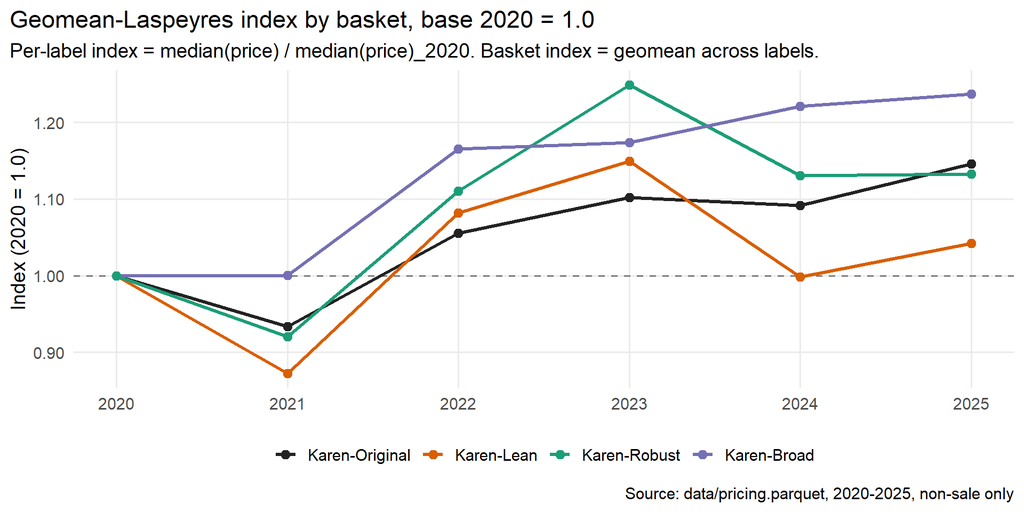

Geomean-Laspeyres index by basket and year (base 2020 = 1.0)

| Basket | Index_2020 | Index_2021 | Index_2022 | Index_2023 | Index_2024 | Index_2025 | % vs 2020_2020 | % vs 2020_2021 | % vs 2020_2022 | % vs 2020_2023 | % vs 2020_2024 | % vs 2020_2025 |
| --- | --- | --- | --- | --- | --- | --- | --- | --- | --- | --- | --- | --- |
| Karen-Broad | 1.000 | 1.000 | 1.166 | 1.174 | 1.221 | 1.237 | +0.0% | +0.0% | +16.6% | +17.4% | +22.1% | +23.7% |
| Karen-Lean | 1.000 | 0.872 | 1.082 | 1.149 | 0.998 | 1.042 | +0.0% | -12.8% | +8.2% | +14.9% | -0.2% | +4.2% |
| Karen-Original | 1.000 | 0.933 | 1.055 | 1.102 | 1.091 | 1.146 | +0.0% | -6.7% | +5.5% | +10.2% | +9.1% | +14.6% |
| Karen-Robust | 1.000 | 0.920 | 1.110 | 1.249 | 1.131 | 1.133 | +0.0% | -8.0% | +11.0% | +24.9% | +13.1% | +13.3% |